# Predictive Model for Movie Revenue Estimation and Decision Support

2023-11-27

```r
knitr::opts_chunk$set(echo = TRUE)
```

Detailed Problem Statement: The movie industry is a dynamic and complex environment where various factors influence a movie’s success, particularly its revenue. This project focuses on developing a robust “Predictive Model for Movie Revenue Estimation and Decision Support.” In an era of high uncertainty and financial risk in the film production business, understanding the determinants of movie revenue is paramount for informed decision-making, investment strategies, and marketing planning.

Movies are a unique combination of artistic expression and commercial ventures. To that end, this research investigates a multitude of features that contribute to the financial performance of a movie. These include aspects like genres, original languages, overview, popularity, production companies, release date, budget, runtime, status, tagline, vote average, vote count, credits, keywords, poster path, backdrop path, and recommendations. Each of these factors is scrutinized meticulously to unravel their individual and collective influence on movie revenue.

By conducting a comprehensive analysis of these features, this research aims to build a regression model (Linear, Decision Tree, Support Vector Machine) based on valuable insights through identifying patterns, relationships, and correlations. The findings of this study are expected to have substantial implications for movie production companies, investors, and stakeholders. They can leverage the predictive model developed in this project to make informed decisions regarding their movie investments, marketing strategies, and financial planning, ultimately contributing to the success and profitability of their ventures in the film industry.

**Importing the Movies Data**

```r
movies = read.csv("C:\\Anand\\Projects_GWU\\DATS6101-P2-Movie-Revenue-Prediction\\movies.csv\\Movie_data.csv")
#head(movies)
summary(movies)
```

```
##        id            title              genres          original_language
##  Min.   :     5   Length:17034       Length:17034       Length:17034
##  1st Qu.: 15766   Class :character   Class :character   Class :character
##  Median :103744   Mode  :character   Mode  :character   Mode  :character
##  Mean   :247898
##  3rd Qu.:442286
##  Max.   :968051
##
##    overview           popularity      production_companies release_date
##  Length:17034       Min.   :   0.60   Length:17034         Length:17034
##  Class :character   1st Qu.:   2.19   Class :character     Class :character
##  Mode  :character   Median :   8.20   Mode  :character     Mode  :character
##                     Mean   :  17.94
##                     3rd Qu.:  15.67
##                     Max.   :8764.00
##
##      budget             revenue             runtime          status
##  Min.   :0.000e+00   Min.   :      -12   Min.   :  0.00   Length:17034
##  1st Qu.:0.000e+00   1st Qu.:   187327   1st Qu.: 90.00   Class :character
##  Median :5.500e+05   Median :  3509438   Median :100.00   Mode  :character
##  Mean   :1.419e+07   Mean   :  9608530   Mean   : 98.58
##  3rd Qu.:1.300e+07   3rd Qu.: 12802098   3rd Qu.:115.75
##  Max.   :5.000e+09   Max.   :292035725   Max.   :999.00
##                                          NA's   :84
##    tagline           vote_average      vote_count        credits
##  Length:17034       Min.   : 0.000   Min.   :    0.0   Length:17034
##  Class :character   1st Qu.: 5.500   1st Qu.:    9.0   Class :character
##  Mode  :character   Median : 6.300   Median :  116.0   Mode  :character
##                     Mean   : 5.839   Mean   :  906.1
##                     3rd Qu.: 7.000   3rd Qu.:  667.0
##                     Max.   :10.000   Max.   :33262.0
##
##    keywords         poster_path        backdrop_path      recommendations
##  Length:17034       Length:17034       Length:17034       Length:17034
##  Class :character   Class :character   Class :character   Class :character
##  Mode  :character   Mode  :character   Mode  :character   Mode  :character
##
##
##
##
##  trailer_views       trailer_likes
##  Min.   :-15645489   Min.   : -705908
##  1st Qu.:    14861   1st Qu.:   53197
##  Median :   597893   Median :  966319
##  Mean   :  2848691   Mean   : 2887057
##  3rd Qu.:  3376453   3rd Qu.: 3717979
##  Max.   :109831055   Max.   :98623355
##
```

```r
movie = movies # Creating a copy of data frame
```

**Removing Unwanted Columns**

```r
library(dplyr)
remove_col <- c(1,5,7,13,16,17,18,19,20)
movie <- movie[, -remove_col]
head(movie)
```

```
##                               title                           genres
## 1                 Meg 2: The Trench    Action-Science Fiction-Horror
## 2               The Pope's Exorcist          Horror-Mystery-Thriller
## 3  Transformers: Rise of the Beasts Action-Adventure-Science Fiction
## 4 Ant-Man and the Wasp: Quantumania Action-Adventure-Science Fiction
## 5                         Creed III                     Drama-Action
## 6                            Fast X            Action-Crime-Thriller
##   original_language popularity release_date   budget  revenue runtime   status
## 1                en   8763.998   2023-08-02 1.29e+08 35205648     116 Released
## 2                en   5953.227   2023-04-05 1.80e+07  6567582     103 Released
## 3                en   5409.104   2023-06-06 2.00e+08 40704546     127 Released
## 4                en   4425.387   2023-02-15 2.00e+08 47576623     125 Released
## 5                en   3994.342   2023-03-01 7.50e+07 26900000     116 Released
## 6                en   3583.861   2023-05-17 3.40e+08 70470966     142 Released
##   vote_average vote_count trailer_views trailer_likes
## 1        7.079       1365      14233995      10661086
## 2        7.433        545       1779581       2007831
## 3        7.340       1007      17747776      13100092
## 4        6.507       2811      29489716      11730700
## 5        7.262       1129       6747268       5175768
## 6        7.275       3694      17676320      25102787
```

**Summary of the data**

```r
new_column_names <- c("Title", "Genre", "Language", "Popularity", "Release_Date","Budget","Revenue","Runtime","Status","Avg_Vote","Vote_Count","Trailer_Views","Trailer_Likes")
colnames(movie) <- new_column_names
summary(movie)
```

```
##     Title              Genre             Language           Popularity
##  Length:17034       Length:17034       Length:17034       Min.   :   0.60
##  Class :character   Class :character   Class :character   1st Qu.:   2.19
##  Mode  :character   Mode  :character   Mode  :character   Median :   8.20
##                                                           Mean   :  17.94
##                                                           3rd Qu.:  15.67
##                                                           Max.   :8764.00
##
##  Release_Date           Budget             Revenue             Runtime
##  Length:17034       Min.   :0.000e+00   Min.   :      -12   Min.   :  0.00
##  Class :character   1st Qu.:0.000e+00   1st Qu.:   187327   1st Qu.: 90.00
##  Mode  :character   Median :5.500e+05   Median :  3509438   Median :100.00
##                     Mean   :1.419e+07   Mean   :  9608530   Mean   : 98.58
##                     3rd Qu.:1.300e+07   3rd Qu.: 12802098   3rd Qu.:115.75
##                     Max.   :5.000e+09   Max.   :292035725   Max.   :999.00
##                                                             NA's   :84
##     Status             Avg_Vote        Vote_Count      Trailer_Views
##  Length:17034       Min.   : 0.000   Min.   :    0.0   Min.   :-15645489
##  Class :character   1st Qu.: 5.500   1st Qu.:    9.0   1st Qu.:    14861
##  Mode  :character   Median : 6.300   Median :  116.0   Median :   597893
##                     Mean   : 5.839   Mean   :  906.1   Mean   :  2848691
##                     3rd Qu.: 7.000   3rd Qu.:  667.0   3rd Qu.:  3376453
##                     Max.   :10.000   Max.   :33262.0   Max.   :109831055
##
##  Trailer_Likes
##  Min.   : -705908
##  1st Qu.:   53197
##  Median :  966319
##  Mean   : 2887057
##  3rd Qu.: 3717979
##  Max.   :98623355
##
```

Inferences: 1. Budget of Movies are having value 0, which is not possible (Remove rows with budget 0) 2. Revenue has negative values which is again not possible (Remove rows with revenue 0 or negative) 3. Runtime of Movies are having value 0, which is not possible (Remove rows with runtime 0) 4. Check for outliers and influential points in all the columns.

**Checking for missing values in the data**

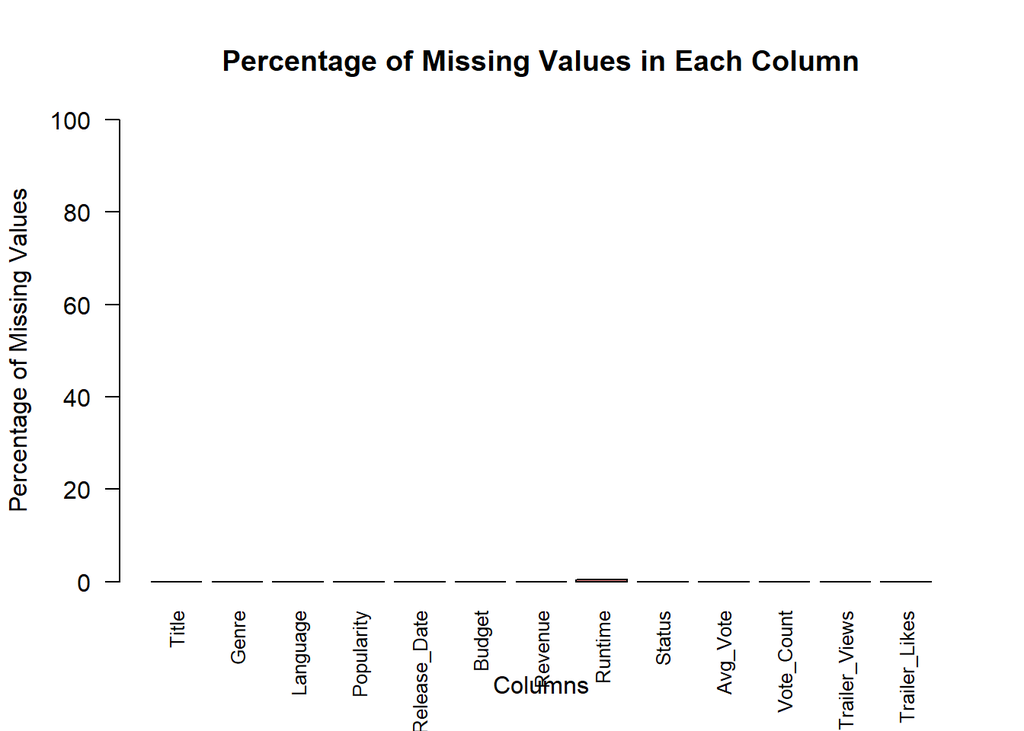

```r
library(ggplot2)

# Calculate the percentage of missing values in each column
column_na_percentages <- colSums(is.na(movie)) / nrow(movie) * 100

# Set a smaller font size
smaller_font_size <- 0.8

# Create a bar plot for the percentage of missing values in each column
barplot(column_na_percentages, main = "Percentage of Missing Values in Each Column",
        xlab = "Columns", ylab = "Percentage of Missing Values",
        col = "lightcoral", border = "black", ylim = c(0, 100),
        names.arg = names(column_na_percentages), las = 2, cex.names = smaller_font_size)
```

```r
print("Rows in Dataset before dropping rows with NA Values")
```

```
## [1] "Rows in Dataset before dropping rows with NA Values"
```

```r
print(nrow(movie))
```

```
## [1] 17034
```

```r
movie <- movie[complete.cases(movie), ]

print("Rows in Dataset After dropping rows with NA Values")
```

```
## [1] "Rows in Dataset After dropping rows with NA Values"
```

```r
print(nrow(movie))
```

```
## [1] 16950
```

Removed rows with NA Values

*Data Cleaning*

```r
print("Rows in Dataset before cleaning")
```

```
## [1] "Rows in Dataset before cleaning"
```

```r
print(nrow(movie))
```

```
## [1] 16950
```

```r
# 1. Remove rows with Budget less than or equal to 0
movie <- movie[movie$Budget > 0, ]

# 2. Remove rows with Revenue less than or equal to 0
movie <- movie[movie$Revenue > 0, ]

# 3. Remove rows with Runtime less than or equal to 0
movie <- movie[movie$Runtime > 0, ]

print("Rows in Dataset After cleaning")
```

```
## [1] "Rows in Dataset After cleaning"
```

```r
print(nrow(movie))
```

```
## [1] 10665
```

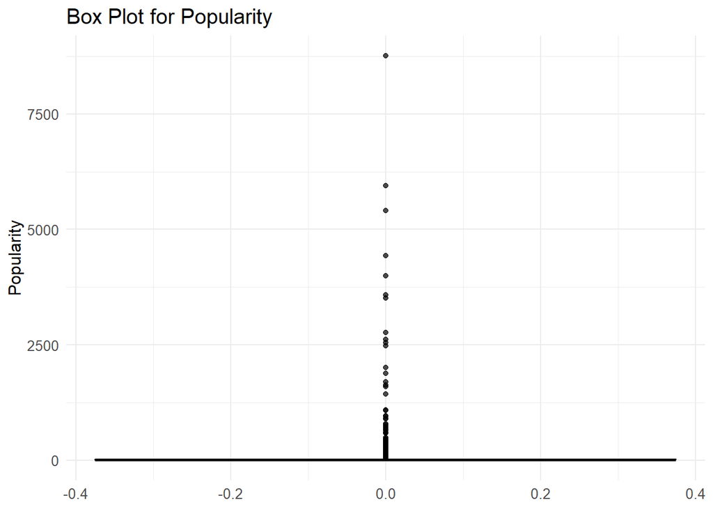

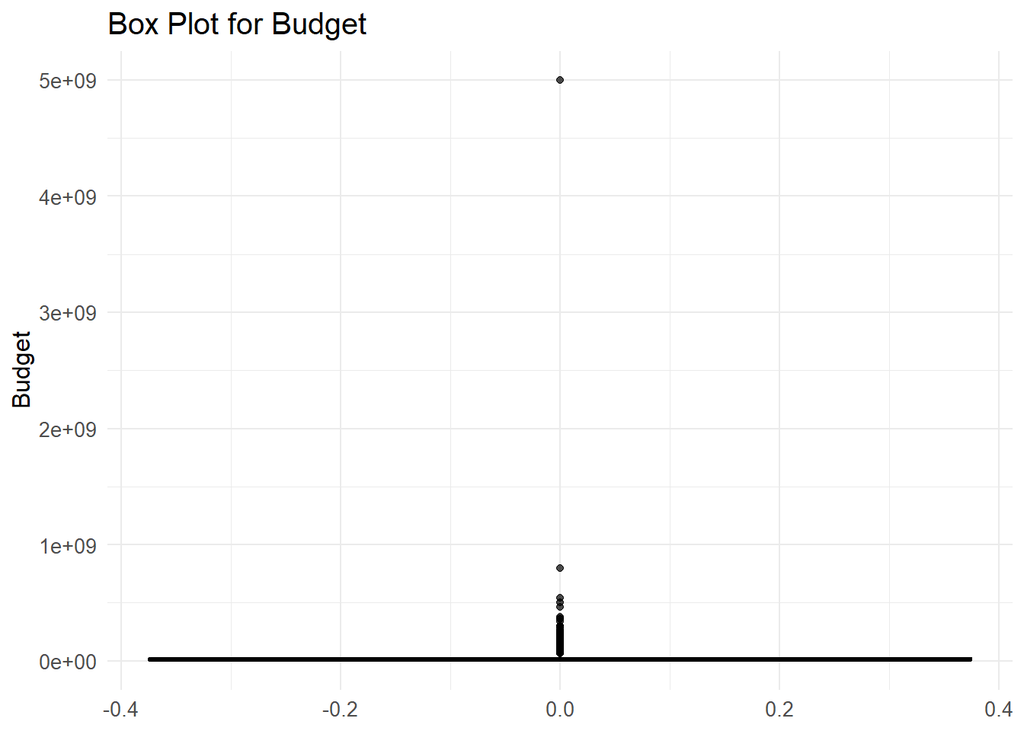

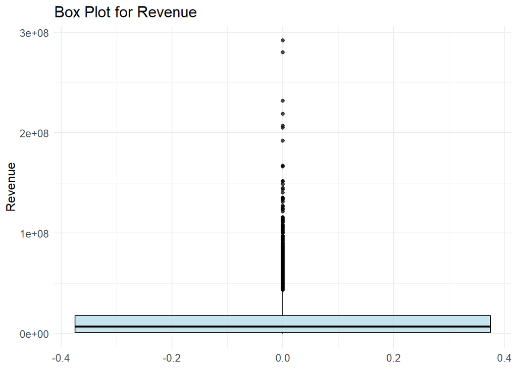

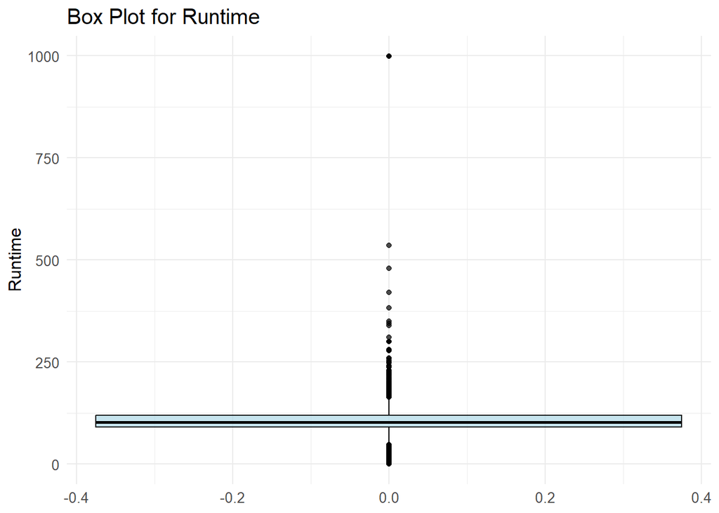

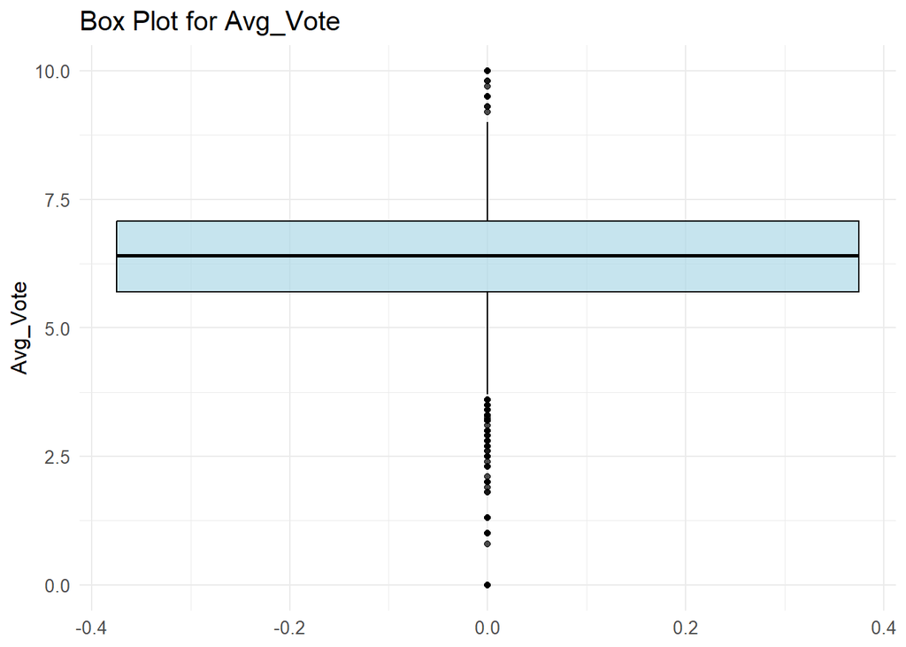

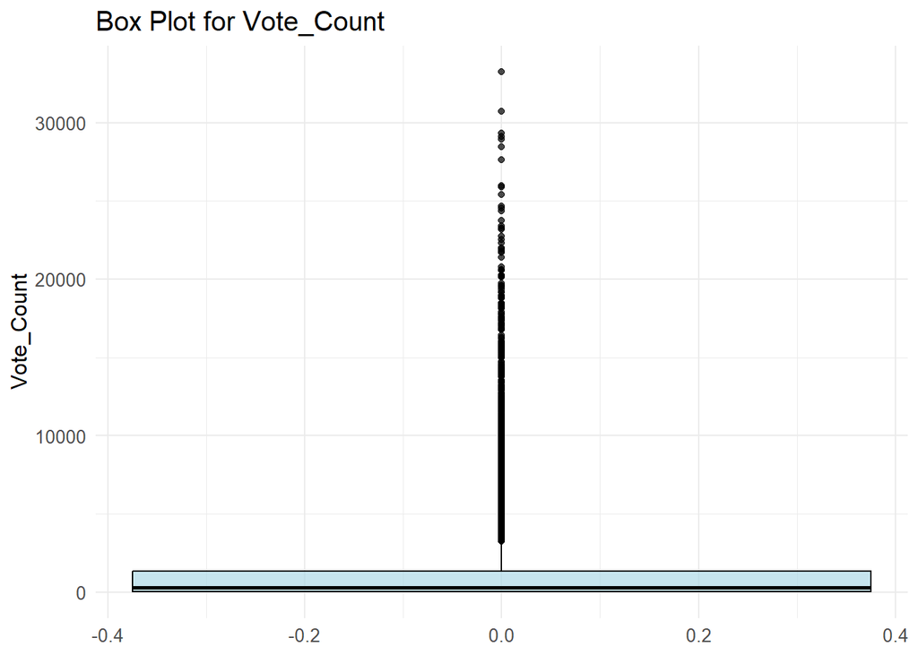

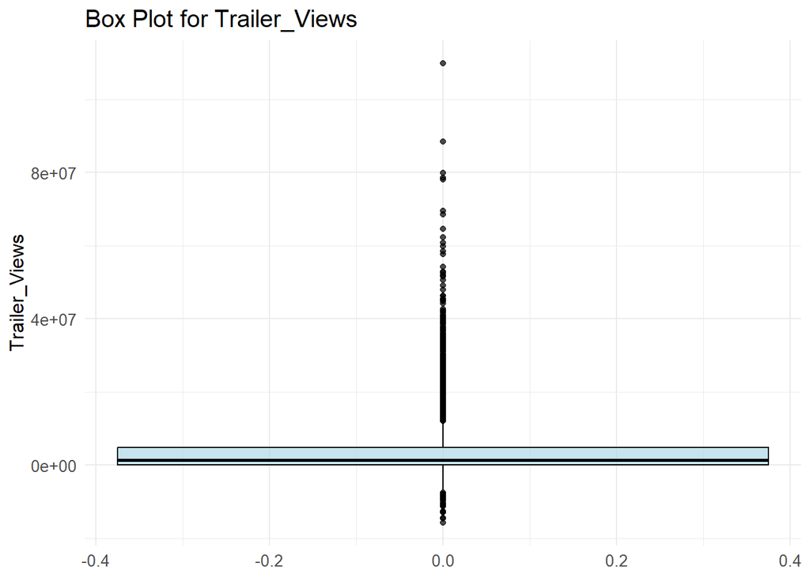

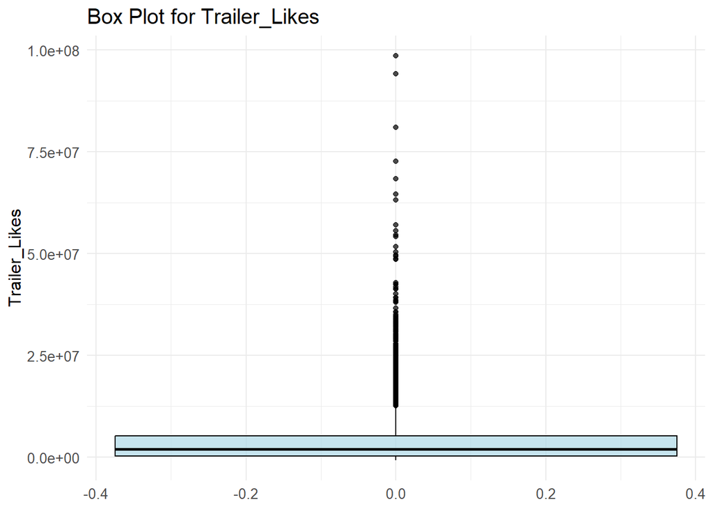

```r
selected_columns <- c("Popularity", "Budget", "Revenue", "Runtime", "Avg_Vote", "Vote_Count", "Trailer_Views","Trailer_Likes")

box_plots_list <- list()

# Create box plots for each selected column
for (col in selected_columns) {
  box_plot <- ggplot(movie, aes(y = get(col))) +
    geom_boxplot(fill = "lightblue", color = "black", alpha = 0.7) +
    labs(title = paste("Box Plot for", col), y = col) +
    theme_minimal() +
    theme(plot.title = element_text(size = 15)) +
    theme(axis.title = element_text(size = 12)) +
    theme(axis.text = element_text(size = 10))

  box_plots_list[[col]] <- box_plot
}

for (col in selected_columns) {
  print(box_plots_list[[col]])
}
```

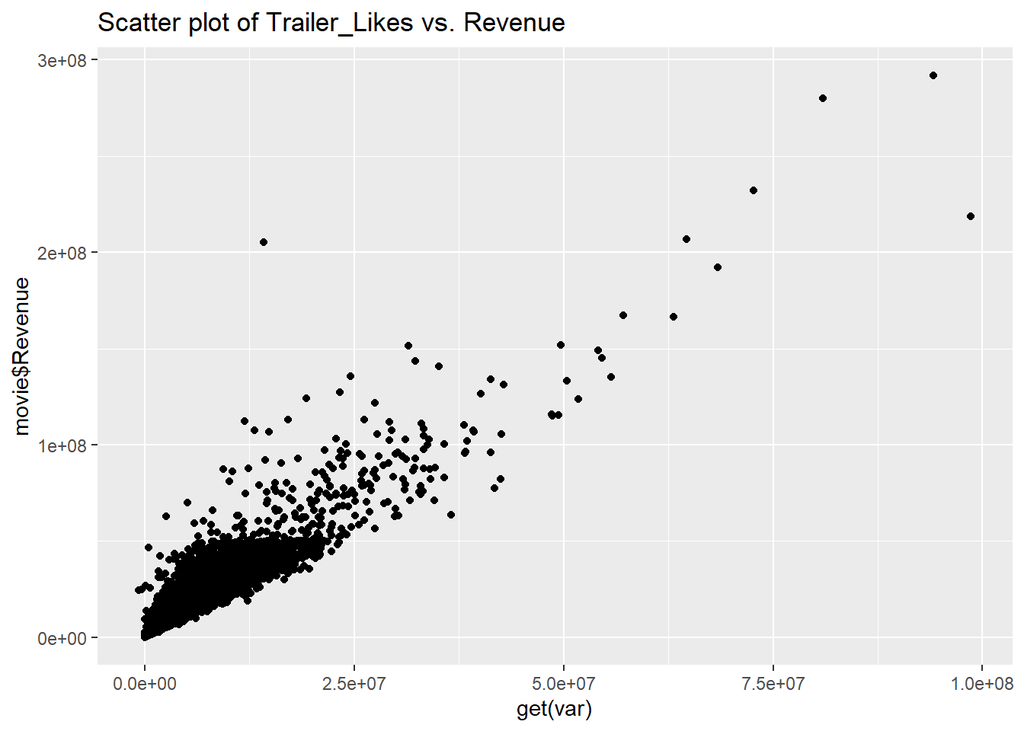

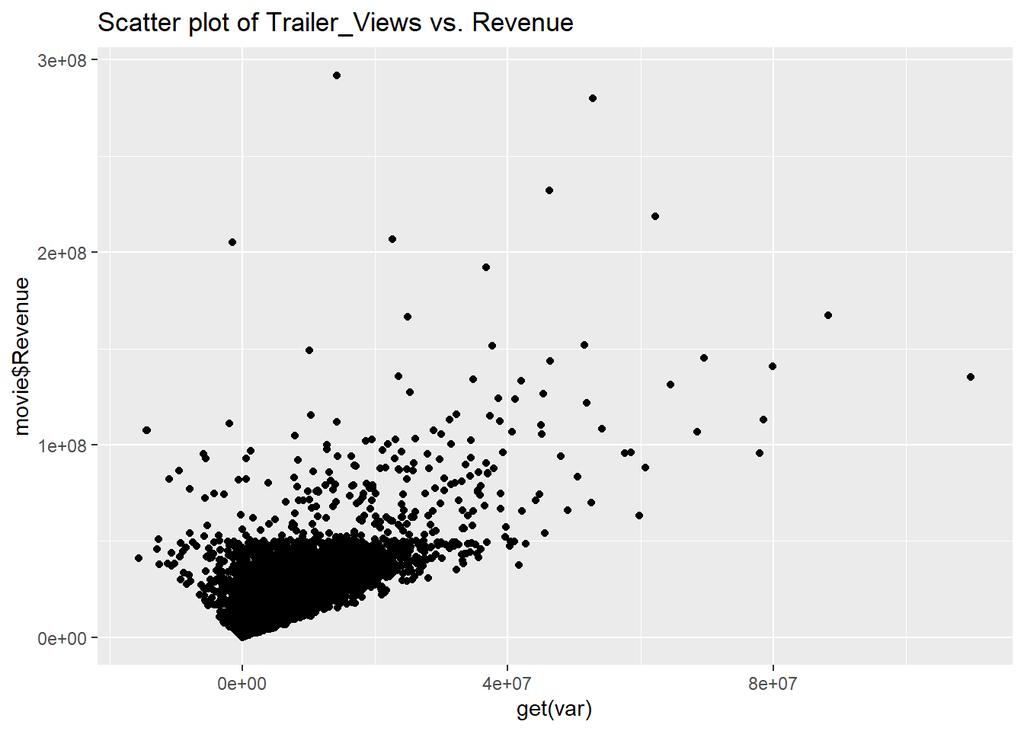

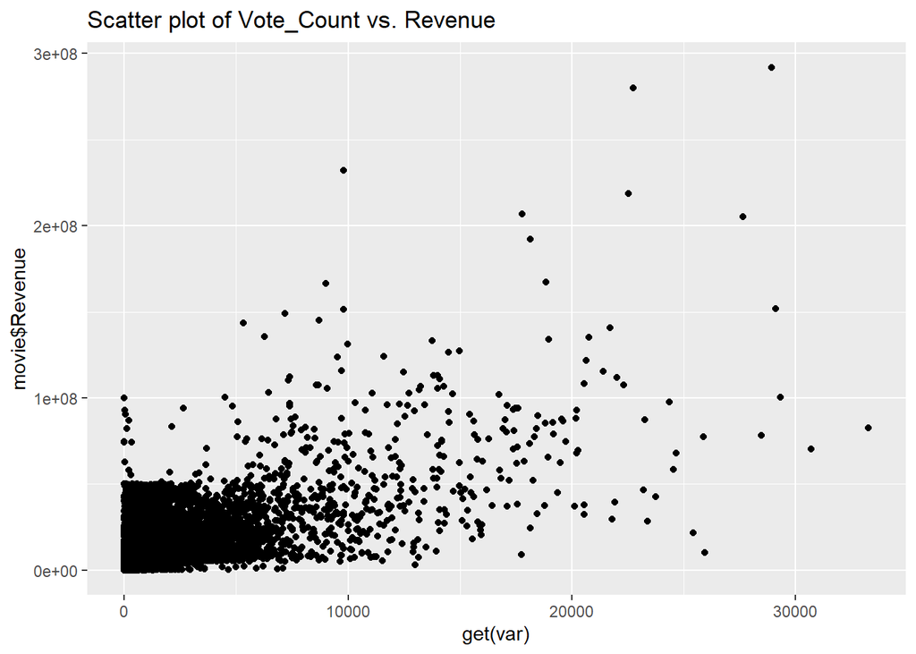

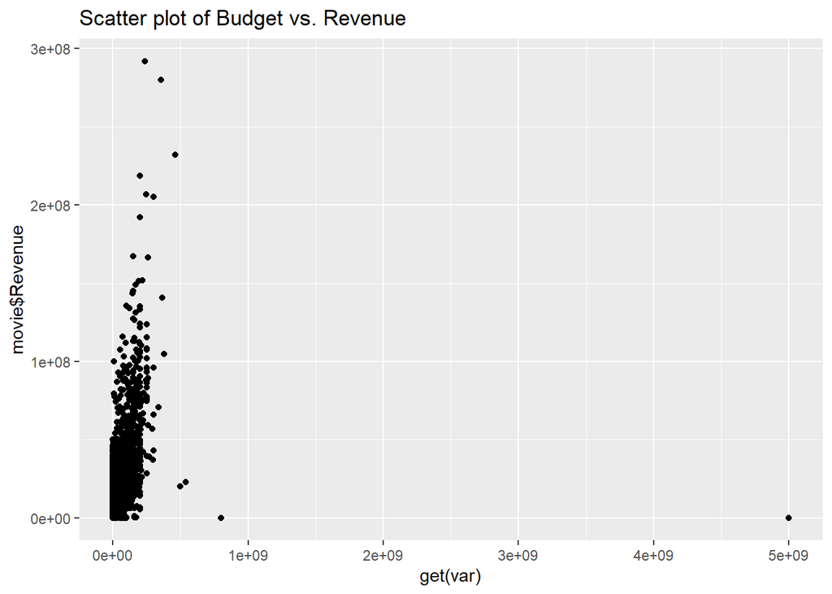

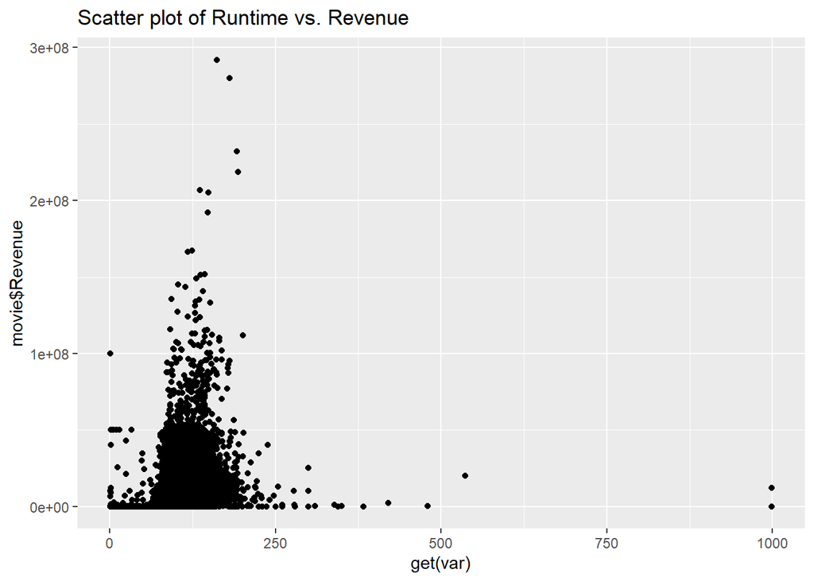

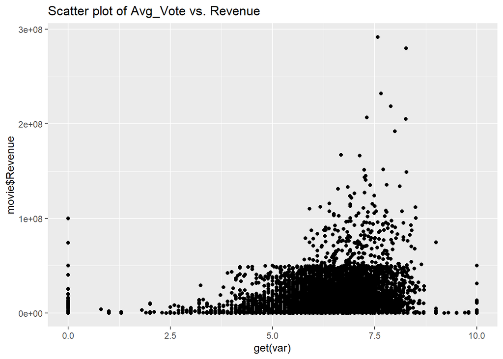

```r
# Scatterplots
# Define the predictors and response variable
predictors <- c("Trailer_Likes", "Trailer_Views", "Vote_Count", "Budget", "Runtime", "Avg_Vote")

scatter_plots <- lapply(predictors, function(var) {
  ggplot(movie, aes(x = get(var), y = movie$Revenue)) +
    geom_point() +
    labs(title = paste("Scatter plot of", var, "vs. Revenue"))
})

# Display scatter plots
scatter_plots
```

**Stepwise Forward Feature Selection**

```r
library(MASS)
# Define your initial model
initial_model <- lm(Revenue ~ 1, data = movie)  # Simple model with intercept only

# Perform stepwise forward selection
final_model <- stepAIC(initial_model, direction = "forward", scope = list(lower = ~1, upper = ~Popularity + Budget + Runtime + Avg_Vote + Vote_Count + Trailer_Views + Trailer_Likes), data = movie)
```

```
## Start:  AIC=355477.5
## Revenue ~ 1
##
##                 Df  Sum of Sq        RSS    AIC
## + Trailer_Likes  1 2.8131e+18 3.7437e+17 332638
## + Trailer_Views  1 1.7462e+18 1.4413e+18 347015
## + Vote_Count     1 1.1910e+18 1.9965e+18 350490
## + Budget         1 4.2200e+17 2.7655e+18 353965
## + Runtime        1 1.5083e+17 3.0366e+18 354963
## + Avg_Vote       1 1.4230e+17 3.0452e+18 354992
## + Popularity     1 5.4809e+16 3.1327e+18 355295
## <none>                        3.1875e+18 355478
##
## Step:  AIC=332637.8
## Revenue ~ Trailer_Likes
##
##                 Df  Sum of Sq        RSS    AIC
## + Trailer_Views  1 3.7240e+16 3.3713e+17 331522
## + Vote_Count     1 2.2369e+16 3.5200e+17 331983
## + Budget         1 6.3802e+15 3.6799e+17 332456
## + Avg_Vote       1 2.1429e+15 3.7222e+17 332579
## + Runtime        1 1.9098e+15 3.7246e+17 332585
## + Popularity     1 1.0322e+15 3.7333e+17 332610
## <none>                        3.7437e+17 332638
##
## Step:  AIC=331522.3
## Revenue ~ Trailer_Likes + Trailer_Views
##
##              Df  Sum of Sq        RSS    AIC
## + Vote_Count  1 1.8075e+16 3.1905e+17 330937
## + Budget      1 4.6603e+15 3.3247e+17 331376
## + Avg_Vote    1 1.5611e+15 3.3557e+17 331475
## + Runtime     1 1.4249e+15 3.3570e+17 331479
## + Popularity  1 7.0240e+14 3.3642e+17 331502
## <none>                     3.3713e+17 331522
##
## Step:  AIC=330936.6
## Revenue ~ Trailer_Likes + Trailer_Views + Vote_Count
##
##              Df  Sum of Sq        RSS    AIC
```

[output cut: 20 more lines]

```
## + Popularity  1 3.1908e+14 3.1623e+17 330848
## + Avg_Vote    1 2.6443e+14 3.1629e+17 330850
## <none>                     3.1655e+17 330857
##
## Step:  AIC=330847.9
## Revenue ~ Trailer_Likes + Trailer_Views + Vote_Count + Budget +
##     Runtime + Popularity
##
##            Df  Sum of Sq        RSS    AIC
## + Avg_Vote  1 2.4634e+14 3.1598e+17 330842
## <none>                   3.1623e+17 330848
##
## Step:  AIC=330841.6
## Revenue ~ Trailer_Likes + Trailer_Views + Vote_Count + Budget +
##     Runtime + Popularity + Avg_Vote
```

```r
# Display the final model summary
summary(final_model)
```

```
##
## Call:
## lm(formula = Revenue ~ Trailer_Likes + Trailer_Views + Vote_Count +
##     Budget + Runtime + Popularity + Avg_Vote, data = movie)
##
## Residuals:
##       Min        1Q    Median        3Q       Max
## -57688193  -1525474   -860778    621761 153418116
##
## Coefficients:
##                Estimate Std. Error t value Pr(>|t|)
## (Intercept)   1.056e+05  1.946e+05   0.543  0.58730
## Trailer_Likes 2.414e+00  1.483e-02 162.792  < 2e-16 ***
## Trailer_Views 3.743e-01  1.145e-02  32.676  < 2e-16 ***
## Vote_Count    5.149e+02  2.386e+01  21.575  < 2e-16 ***
## Budget        6.945e-03  9.360e-04   7.420 1.26e-13 ***
## Runtime       6.210e+03  1.488e+03   4.174 3.02e-05 ***
## Popularity    1.082e+03  3.397e+02   3.186  0.00145 **
## Avg_Vote      7.640e+04  2.650e+04   2.882  0.00395 **
## ---
## Signif. codes:  0 '***' 0.001 '**' 0.01 '*' 0.05 '.' 0.1 ' ' 1
##
## Residual standard error: 5445000 on 10657 degrees of freedom
## Multiple R-squared:  0.9009, Adjusted R-squared:  0.9008
## F-statistic: 1.384e+04 on 7 and 10657 DF,  p-value: < 2.2e-16
```

```r
lm_model_usingFFS <- lm(Revenue ~ Trailer_Likes + Trailer_Views + Vote_Count + Budget + Runtime + Avg_Vote, data = movie)

# Summarize the model
summary(lm_model_usingFFS)
```

```
##
## Call:
## lm(formula = Revenue ~ Trailer_Likes + Trailer_Views + Vote_Count +
##     Budget + Runtime + Avg_Vote, data = movie)
##
## Residuals:
##       Min        1Q    Median        3Q       Max
## -57802277  -1528903   -863713    625671 153480191
##
## Coefficients:
##                Estimate Std. Error t value Pr(>|t|)
## (Intercept)   9.487e+04  1.947e+05   0.487  0.62602
## Trailer_Likes 2.415e+00  1.483e-02 162.913  < 2e-16 ***
## Trailer_Views 3.751e-01  1.146e-02  32.739  < 2e-16 ***
## Vote_Count    5.164e+02  2.387e+01  21.633  < 2e-16 ***
## Budget        7.151e-03  9.342e-04   7.655 2.10e-14 ***
## Runtime       6.254e+03  1.488e+03   4.202 2.67e-05 ***
## Avg_Vote      7.911e+04  2.650e+04   2.985  0.00284 **
## ---
## Signif. codes:  0 '***' 0.001 '**' 0.01 '*' 0.05 '.' 0.1 ' ' 1
##
## Residual standard error: 5448000 on 10658 degrees of freedom
## Multiple R-squared:  0.9008, Adjusted R-squared:  0.9007
## F-statistic: 1.613e+04 on 6 and 10658 DF,  p-value: < 2.2e-16
```

In the above model we can see that all the input features are significant and we have a good Multiple R-Squared value. The p-value for the model is also significant indicating the model is a significant model. The Residual Std Error is around 5.4 Million which seems a little high as we cannot exactly predict the Revenue of a Movie as it depends on various other factors.

```r
library(caret)
# Set the seed for reproducibility
set.seed(123)

# Define the predictors and response variable
predictors <- c("Trailer_Likes", "Trailer_Views", "Vote_Count", "Budget", "Runtime", "Avg_Vote")
response <- "Revenue"

# Create a training and testing dataset
train_index <- createDataPartition(movie$Revenue, p = 0.8, list = FALSE)
train_data <- movie[train_index, ]
test_data <- movie[-train_index, ]

# Fit the model on the training data
model <- lm(paste(response, "~", paste(predictors, collapse = " + ")), data = train_data)

# Make predictions on the test data
predictions <- predict(model, newdata = test_data)

# Calculate RMSE
rmse <- sqrt(mean((test_data$Revenue - predictions)^2))

# Print the RMSE
cat("Root Mean Squared Error (RMSE):", rmse, "\n")
```

```
## Root Mean Squared Error (RMSE): 5479066
```

```r
lm_model <- lm(Revenue ~ Trailer_Views+Trailer_Likes, data = movie)

# Summarize the model
summary(lm_model)
```

```
##
## Call:
## lm(formula = Revenue ~ Trailer_Views + Trailer_Likes, data = movie)
##
## Residuals:
##       Min        1Q    Median        3Q       Max
## -62522192  -1378274  -1207659    726234 167912267
##
## Coefficients:
##                Estimate Std. Error t value Pr(>|t|)
## (Intercept)   1.320e+06  6.653e+04   19.85   <2e-16 ***
## Trailer_Views 4.039e-01  1.177e-02   34.32   <2e-16 ***
## Trailer_Likes 2.584e+00  1.383e-02  186.87   <2e-16 ***
## ---
## Signif. codes:  0 '***' 0.001 '**' 0.01 '*' 0.05 '.' 0.1 ' ' 1
##
## Residual standard error: 5623000 on 10662 degrees of freedom
## Multiple R-squared:  0.8942, Adjusted R-squared:  0.8942
## F-statistic: 4.507e+04 on 2 and 10662 DF,  p-value: < 2.2e-16
```

```r
library(caTools)

# Set a random seed for reproducibility
set.seed(123)

# Split the data into training (80%) and testing (20%) sets
split <- sample.split(movie$Revenue, SplitRatio = 0.8)
train_data <- subset(movie, split == TRUE)
test_data <- subset(movie, split == FALSE)

# Fit linear regression model on the training data
lm_model <- lm(Revenue ~ Trailer_Views+Trailer_Likes, data = train_data)

# Make predictions on the test data
predictions <- predict(lm_model, newdata = test_data)

# Calculate Root Mean Squared Error (RMSE)
rmse <- sqrt(mean((test_data$Revenue - predictions)^2))
cat("Root Mean Squared Error (RMSE):", rmse, "\n")
```

```
## Root Mean Squared Error (RMSE): 5065163
```

```r
mean_revenue <- mean(movie$Revenue, na.rm = TRUE)
median_revenue <- median(movie$Revenue, na.rm = TRUE)
quantiles_revenue <- quantile(movie$Revenue, c(0.25, 0.5, 0.75), na.rm = TRUE)

# Print the results
cat("Mean Revenue:", mean_revenue, "\n")
```

```
## Mean Revenue: 12767753
```

```r
cat("Median Revenue:", median_revenue, "\n")
```

```
## Median Revenue: 7123919
```

```r
cat("Quantiles (25%, 50%, 75%):", quantiles_revenue, "\n")
```

```
## Quantiles (25%, 50%, 75%): 930000 7123919 17921343
```